# Exercise 02 — Validating the Super Simple Ecosystem Model

Fluxcourse 2026 · Bloomington, Indiana

```r
cat("Date:", format(Sys.time(), "%Y-%m-%d %H:%M"), "\n")
```

```
## Date: 2026-06-08 13:08
```

```r
cat("Commit:", system("git rev-parse --short HEAD", intern = TRUE), "\n")
```

```
## Commit: c99ab96
```

## Introduction

Running a model and validating a model are different activities. In Exercise 01 you ran SSEM at two contrasting forest sites — US-NR1 (Niwot Ridge, an ENF) and US-MMS (Morgan Monroe, a DBF) — and confirmed the output looks plausible. That is a necessary first step, but it is not validation: the model could produce any seasonal cycle you chose simply by adjusting its parameters, and there is no way to know whether its numbers are right without confronting them with independent observations. Validation requires data that the model has not already seen, measured at a spatial and temporal scale that actually matches what the model simulates, and processed consistently enough that you are comparing the same quantity. Each of those three conditions is harder to satisfy than it sounds.

## Setup

> **Before you start:** This exercise loads the SSEM ensemble output arrays that were computed in Exercise 01. To make those files available, open `exercises/01_run_model.Rmd`, knit it once to completion. The following files should be saved automatically:

> ```r
> saveRDS(output_nr1, file.path(data_dir, "ssem_usnr1_2008.rds"))
> saveRDS(output_mms, file.path(data_dir, "ssem_usmms_2008.rds"))
> ```

> Once those files exist on disk, this document is self-contained.

```r
library(tidyverse)   # dplyr, ggplot2, readr, tidyr, purrr, lubridate wrapper
library(lubridate)   # date arithmetic, ymd(), days_in_month()

# ── Paths ─────────────────────────────────────────────────────────────────────
# Set this to your local data folder path.
# Example for Google Drive on Mac:
# data_dir <- "~/Google Drive/My Drive/Fluxcourse/.../Tuesday_AM_SSEM_part1"
data_dir <- "../data"  # default for codespace

# code_dir points to the R/ folder containing functions.R and utils.R.
code_dir <- "../R"

# R/functions.R: SSEM model, ensemble_forecast, plot_forecast, rdirichlet.orig,
# flux.uncertainty, varnames/units character vectors, ParticleFilter
source(file.path(code_dir, "functions.R"))

# R/utils.R: ciEnvelope, col.alpha, wtd.quantile, solar_geom, mat2mcmc.list
source(file.path(code_dir, "utils.R"))

# ── Load SSEM ensemble outputs from Exercise 01 ────────────────────────────────
# ensemble_forecast() returns a 3-D array [timestep × ensemble × variable].
# We read both from disk so this document does not need to re-run the model.

load_ssem <- function(path) {
  if (file.exists(path)) {
    out <- readRDS(path)
    cat("SSEM output loaded:", path, "—", paste(dim(out), collapse = " × "),
        "[timesteps × ensemble × variables]\n")
    out
  } else {
    stop(paste(
      "File not found:", path, "\n\n",
      "Please knit 01_run_model.Rmd first, then re-knit this document."
    ))
  }
}

output_nr1 <- load_ssem(file.path(data_dir, "ssem_usnr1_2008.rds"))
```

```
## SSEM output loaded: ../data/ssem_usnr1_2008.rds — 17568 × 100 × 12 [timesteps × ensemble × variables]
```

```r
output_mms <- load_ssem(file.path(data_dir, "ssem_usmms_2008.rds"))
```

```
## SSEM output loaded: ../data/ssem_usmms_2008.rds — 8784 × 100 × 12 [timesteps × ensemble × variables]
```

```r
# ── Site timestep intervals ────────────────────────────────────────────────────
# Each flux tower site uses a different sub-daily measurement frequency.
# This list is the single source of truth used downstream in the harmonize chunk
# to convert instantaneous flux rates (μmol CO₂ m⁻² s⁻¹) to per-timestep totals
# (gC m⁻² per step) and ultimately to daily totals (gC m⁻² day⁻¹).
#
# Getting the timestep wrong introduces a proportional error in every flux
# integral. For US-MMS vs US-NR1, using the same constant for both would halve
# or double one site's daily totals — making two forests look very different for
# a purely methodological reason.
#
# US-NR1: half-hourly AmeriFlux product — 30 min intervals, 48 rows per day,
#   1800 seconds per timestep.
# US-MMS: hourly AmeriFlux product — 60 min intervals, 24 rows per day,
#   3600 seconds per timestep.
# DE-Tha / DK-Sor: half-hourly FLUXNET product — 30 min (extension sites).
site_timestep <- list(
  "US-NR1" = 30,   # minutes per timestep (half-hourly)
  "US-MMS" = 60,   # minutes per timestep (hourly)
  "DE-Tha" = 30,   # minutes per timestep (half-hourly) — extension site
  "DK-Sor" = 30    # minutes per timestep (half-hourly) — extension site
)
```

## Load raw observations

> The code below loads every data source exactly as it arrives — no unit conversions yet. Read the column names and the raw values carefully. You are about to encounter one of the most routine but under-discussed problems in multi-source model evaluation: every system uses different units, different sign conventions, and different time resolutions. Before you can compare anything, you must understand what you have.

```r
# ── Sub-daily FLUXNET data — US-NR1 (primary ENF site) ───────────────────────
# US-NR1_HH.csv — half-hourly (30 min), timestamp column: DATETIME_START
#   ISO 8601 format ("1998-01-01T00:00:00Z"); processed by the fluxnet package.
#   Site: subalpine ENF, Niwot Ridge, Colorado; coverage 1998–2025.
#   File uses _HH_ (ICOS/FLUXNET half-hourly convention), not _HR_ (hourly).
#
# IMPORTANT — US-NR1 NEE variable: this site uses NEE_CUT_REF rather than
# NEE_VUT_REF.  See the explicit note in the US-NR1 section below for the
# full explanation.  col_select loads NEE_CUT_REF and NEE_CUT_REF_QC here.
usnr1_hr_raw <- read_csv(
  file.path(data_dir, "US-NR1", "US-NR1_HH.csv"),
  show_col_types = FALSE,
  col_select = c(DATETIME_START, NEE_CUT_REF, NEE_CUT_REF_QC)
)

# ── Sub-daily FLUXNET data — US-MMS (primary DBF site) ────────────────────────
# US-MMS_HR.csv — hourly (60 min), timestamp column: TIMESTAMP_START
#   Integer format YYYYMMDDHHMM (e.g., 199901010000 = midnight 1 Jan 1999).
#   Site: temperate DBF, Morgan Monroe State Forest, Indiana; coverage 1999–2023.
usmms_hr_raw <- read_csv(
  file.path(data_dir, "US-MMS", "US-MMS_HR.csv"),
  show_col_types = FALSE,
  col_select = c(TIMESTAMP_START, NEE_VUT_REF, NEE_VUT_REF_QC)
)

# ── Extension sites (DE-Tha and DK-Sor) — load if files exist ─────────────────
# These European sites are not required for the primary analysis below but
# remain available for students who want to compare across more sites.
# They use FLUXNET HH half-hourly products with DATETIME_START timestamps.
detha_hh_raw <- if (file.exists(file.path(data_dir, "DE-Tha", "DE-Tha_HH.csv"))) {
  read_csv(file.path(data_dir, "DE-Tha", "DE-Tha_HH.csv"), show_col_types = FALSE,
           col_select = c(DATETIME_START, NEE_VUT_REF, NEE_VUT_REF_QC))
} else { NULL }

dksor_hh_raw <- if (file.exists(file.path(data_dir, "DK-Sor", "DK-Sor_HH.csv"))) {
  read_csv(file.path(data_dir, "DK-Sor", "DK-Sor_HH.csv"), show_col_types = FALSE,
           col_select = c(DATETIME_START, NEE_VUT_REF, NEE_VUT_REF_QC))
} else { NULL }

# ── Replace FLUXNET fill value -9999 with NA ──────────────────────────────────
# across(where(is.numeric)) catches every numeric column in one call.
replace_fluxnet_na <- function(df) {
  df |> mutate(across(where(is.numeric), \(x) replace(x, x == -9999, NA)))
}
usnr1_hr_raw <- replace_fluxnet_na(usnr1_hr_raw)
usmms_hr_raw <- replace_fluxnet_na(usmms_hr_raw)
if (!is.null(detha_hh_raw)) detha_hh_raw <- replace_fluxnet_na(detha_hh_raw)
if (!is.null(dksor_hh_raw)) dksor_hh_raw <- replace_fluxnet_na(dksor_hh_raw)

# ── US-MMS daily (DD) for CMIP6 Chunk 6 compatibility ────────────────────────
# The CMIP6 comparison chunk (below) uses daily-resolution GPP/RECO data
# from the US-MMS DD product.
usmms_raw <- read_csv(file.path(data_dir, "US-MMS", "US-MMS_DD.csv"),
                      show_col_types = FALSE)

# ── CMIP6 monthly output (all three models, all four sites) ───────────────────
# Pre-extracted from the Pangeo CMIP6 catalog (extract_cmip6_allsites.py).
# One row per month; carbon flux units: kg C m⁻² s⁻¹.
# Available for US-NR1, US-MMS, DE-Tha, DK-Sor — three ESMs each.
#
# site_file_id converts a site ID to the token used in the CSV filenames:
#   "US-NR1" → "usnr1", "US-MMS" → "usmms", "DE-Tha" → "detha", "DK-Sor" → "dksor"
site_file_id <- function(site_id) tolower(gsub("-", "", site_id))

# Load all three models for both primary sites at once.
# DE-Tha and DK-Sor are loaded in the CMIP6 comparison chunk on demand.
load_cmip6_site <- function(site_id) {
  fid <- site_file_id(site_id)
  models <- c("CESM2", "IPSL-CM6A-LR", "UKESM1-0-LL")
  purrr::map_dfr(models, \(m) {
    path <- file.path(data_dir, "cmip6", paste0(m, "_", fid, "_monthly.csv"))
    df <- read_csv(path, show_col_types = FALSE)
    dplyr::mutate(df, model = m, .before = everything())
  })
}

cmip6_nr1_raw <- load_cmip6_site("US-NR1")   # 3 models × 504 months (historical+SSP)
cmip6_mms_raw <- load_cmip6_site("US-MMS")   # as above

# ── Discovery: print the unit and format situation ────────────────────────────
cat("── Sub-daily FLUXNET: loaded file sizes ────────────────────────────────\n")
```

```
## ── Sub-daily FLUXNET: loaded file sizes ────────────────────────────────
```

```r
cat(sprintf("  US-NR1 HR rows: %s (1998–2025, 30 min)\n",
            format(nrow(usnr1_hr_raw), big.mark = ",")))
```

```
##   US-NR1 HR rows: 490,896 (1998–2025, 30 min)
```

```r
cat(sprintf("  US-MMS HR rows: %s (1999–2023, 60 min)\n",
            format(nrow(usmms_hr_raw), big.mark = ",")))
```

```
##   US-MMS HR rows: 219,144 (1999–2023, 60 min)
```

```r
cat("\n── Sub-daily FLUXNET: carbon flux columns ──────────────────────────────\n")
```

```
##
## ── Sub-daily FLUXNET: carbon flux columns ──────────────────────────────
```

```r
cat("  US-NR1: NEE_CUT_REF       μmol CO₂ m⁻² s⁻¹    (see note below)\n")
```

```
##   US-NR1: NEE_CUT_REF       μmol CO₂ m⁻² s⁻¹    (see note below)
```

```r
cat("  US-NR1: NEE_CUT_REF_QC    integer QC flag\n")
```

```
##   US-NR1: NEE_CUT_REF_QC    integer QC flag
```

```r
cat("  US-MMS: NEE_VUT_REF       μmol CO₂ m⁻² s⁻¹    Instantaneous rate; + = source\n")
```

```
##   US-MMS: NEE_VUT_REF       μmol CO₂ m⁻² s⁻¹    Instantaneous rate; + = source
```

```r
cat("  US-MMS: NEE_VUT_REF_QC    integer QC flag\n")
```

```
##   US-MMS: NEE_VUT_REF_QC    integer QC flag
```

```r
cat("  Timestamp column:\n")
```

```
##   Timestamp column:
```

```r
cat("    US-NR1:       DATETIME_START  (ISO 8601, e.g. 1998-01-01T00:00:00Z)\n")
```

```
##     US-NR1:       DATETIME_START  (ISO 8601, e.g. 1998-01-01T00:00:00Z)
```

```r
cat("    US-MMS:       TIMESTAMP_START (integer YYYYMMDDHHMM, e.g. 199901010000)\n")
```

```
##     US-MMS:       TIMESTAMP_START (integer YYYYMMDDHHMM, e.g. 199901010000)
```

```r
cat("\n── CMIP6 monthly: key columns ──────────────────────────────────────────\n")
```

```
##
## ── CMIP6 monthly: key columns ──────────────────────────────────────────
```

```r
cat("  gpp_kgC_m2_s     kg C m⁻² s⁻¹  (very different from FLUXNET μmol units)\n")
```

```
##   gpp_kgC_m2_s     kg C m⁻² s⁻¹  (very different from FLUXNET μmol units)
```

```r
cat(sprintf("  US-NR1 CMIP6 rows: %d  (3 models × months)\n", nrow(cmip6_nr1_raw)))
```

```
##   US-NR1 CMIP6 rows: 1428  (3 models × months)
```

```r
cat(sprintf("  US-MMS CMIP6 rows: %d  (3 models × months)\n", nrow(cmip6_mms_raw)))
```

```
##   US-MMS CMIP6 rows: 1428  (3 models × months)
```

```r
cat("\n── SSEM output (from Exercise 01) ──────────────────────────────────────\n")
```

```
##
## ── SSEM output (from Exercise 01) ──────────────────────────────────────
```

```r
cat("  GPP [dim 3 = 5]  μmol CO₂ m⁻² s⁻¹  (rate at each timestep)\n")
```

```
##   GPP [dim 3 = 5]  μmol CO₂ m⁻² s⁻¹  (rate at each timestep)
```

```r
cat("  NEP [dim 3 = 6]  μmol CO₂ m⁻² s⁻¹  (positive = ecosystem gaining C)\n")
```

```
##   NEP [dim 3 = 6]  μmol CO₂ m⁻² s⁻¹  (positive = ecosystem gaining C)
```

```r
cat("  Negate NEP → NEE so sign convention matches FLUXNET (done in harmonize).\n")
```

```
##   Negate NEP → NEE so sign convention matches FLUXNET (done in harmonize).
```

> **US-NR1 note: NEE_CUT_REF not NEE_VUT_REF.**

> At most FLUXNET sites, the recommended NEE variable is `NEE_VUT_REF`, where VUT stands for “variable u* threshold” — a method that estimates the critical wind speed below which turbulent mixing is insufficient to accurately measure fluxes, and applies a site-specific threshold that varies by season. At US-NR1, the VUT method was not applied to this product version; the available NEE variable is `NEE_CUT_REF`, where CUT stands for “constant u* threshold” — a single fixed threshold applied uniformly across the record. Both methods serve the same purpose (filtering low-turbulence periods when NEE measurements are unreliable), but VUT is generally preferred for long records because it captures interannual variability in atmospheric stability. When comparing US-NR1 against other sites, keep this difference in mind; it does not invalidate the data but adds a small source of uncertainty in the gap-filled values.

## Unit harmonization

> **A note on embedded assumptions.** Every unit conversion below is also a scientific decision. Multiplying a half-hourly rate by 1800 seconds assumes the rate was constant over that 30-minute window — true for FLUXNET gap-filled data by construction, but an approximation for the model. Negating SSEM’s NEP to produce an NEE-convention value embeds the assumption that storage fluxes are negligible — reasonable at the daily timescale, questionable at sub-hourly timescales. Read each conversion below and make sure you understand both the arithmetic and the assumption it encodes.

```r
# ━━━━━━━━━━━━━━━━━━━━━━━━━━━━━━━━━━━━━━━━━━━━━━━━━━━━━━━━━━━━━━━━━━━━━━━━━━━
# CONVERSION CONSTANTS (centralised per CLAUDE.md — define once, use everywhere)
# ━━━━━━━━━━━━━━━━━━━━━━━━━━━━━━━━━━━━━━━━━━━━━━━━━━━━━━━━━━━━━━━━━━━━━━━━━━━

# Molar mass of carbon in grams per micromole CO₂
MC <- 12e-6   # gC μmol⁻¹

# Seconds per minute
SECS_PER_MIN <- 60L

# Per-site conversion: μmol CO₂ m⁻² s⁻¹ (instantaneous rate) → gC m⁻² per step.
# Formula: MC × timestep_length_in_minutes × SECS_PER_MIN
#
# US-NR1 (30-min): 12e-6 × 30 × 60 = 0.0216 gC per step
# US-MMS (60-min): 12e-6 × 60 × 60 = 0.0432 gC per step
#
# Using the same constant for both would halve or double one site's daily totals,
# making two forests appear to have very different carbon balances for a purely
# methodological reason — a common error in multi-site model-data comparison.
umol_s_to_gC_step <- function(site) {
  MC * site_timestep[[site]] * SECS_PER_MIN
}

# Daily average rate → daily total (used for CMIP6 comparisons)
UMOL_S_TO_GC_DAY <- MC * 86400            # μmol m⁻² s⁻¹ → gC m⁻² day⁻¹ = 1.0368
KGC_S_TO_GC_DAY  <- 1000 * 86400          # kg C m⁻² s⁻¹ → gC m⁻² day⁻¹ = 86400000
MGC_HA_TO_KGC_M2 <- 1000 / 10000          # Mg C ha⁻¹ → kg C m⁻² = 0.1

# ━━━━━━━━━━━━━━━━━━━━━━━━━━━━━━━━━━━━━━━━━━━━━━━━━━━━━━━━━━━━━━━━━━━━━━━━━━━
# PART A — SSEM: produce sub-daily and daily representations for both sites
# ━━━━━━━━━━━━━━━━━━━━━━━━━━━━━━━━━━━━━━━━━━━━━━━━━━━━━━━━━━━━━━━━━━━━━━━━━━━

build_ssem_daily <- function(ssem_out, site_label, run_year, steps_per_day) {
  # ssem_out:      3-D array [timestep × ensemble × variable]
  # site_label:    "US-NR1" or "US-MMS"
  # run_year:      integer calendar year
  # steps_per_day: 48 (half-hourly, US-NR1) or 24 (hourly, US-MMS)

  n_steps    <- dim(ssem_out)[1]
  step_mins  <- site_timestep[[site_label]]
  step_conv  <- umol_s_to_gC_step(site_label)

  # Use integer division so any partial day at the end is safely trimmed.
  n_days    <- n_steps %/% steps_per_day
  n_use     <- n_days * steps_per_day
  if (n_use < n_steps) {
    message(sprintf("%s: trimming %d partial timesteps to %d complete days.",
                    site_label, n_steps - n_use, n_days))
    ssem_out <- ssem_out[seq_len(n_use), , , drop = FALSE]
    n_steps  <- n_use
  }

  # Datetime vector aligned to the first timestep of the run year
  ssem_dt <- seq(
    from       = as.POSIXct(sprintf("%d-01-01 00:00:00", run_year), tz = "UTC"),
    by         = paste(step_mins, "mins"),
    length.out = n_steps
  )

  # Variable 6 = NEP (positive = C sink). Negate to match FLUXNET sign convention.
  nee_raw <- -ssem_out[,, 6]   # [n_steps × ne], μmol CO₂ m⁻² s⁻¹

  # Sub-daily: ensemble 2.5%, 50%, 97.5% at each timestep
  sd_ci <- apply(nee_raw, 1, quantile, c(0.025, 0.5, 0.975), na.rm = TRUE)
  ssem_sd <- tibble(
    datetime = ssem_dt,
    date     = as.Date(ssem_dt),
    site     = site_label,
    nee_med  = sd_ci["50%",  ],
    nee_lo   = sd_ci["2.5%", ],
    nee_hi   = sd_ci["97.5%",]
  )

  # Daily aggregation
  day_idx <- rep(seq_len(n_days), each = steps_per_day)
  dates   <- seq.Date(as.Date(sprintf("%d-01-01", run_year)), by = "day",
                      length.out = n_days)

  daily_nee <- apply(nee_raw, 2, \(e) tapply(e, day_idx, sum) * step_conv)
  daily_gpp <- apply(ssem_out[,, 5], 2, \(e) tapply(e, day_idx, sum) * step_conv)
  nee_ci <- apply(daily_nee, 1, quantile, c(0.025, 0.5, 0.975), na.rm = TRUE)
  gpp_ci <- apply(daily_gpp, 1, quantile, c(0.025, 0.5, 0.975), na.rm = TRUE)

  ssem_dd <- tibble(
    date    = dates,
    site    = site_label,
    nee_med = nee_ci["50%",  ],
    nee_lo  = nee_ci["2.5%", ],
    nee_hi  = nee_ci["97.5%",],
    gpp_med = gpp_ci["50%",  ],
    gpp_lo  = gpp_ci["2.5%", ],
    gpp_hi  = gpp_ci["97.5%",]
  )

  cat(sprintf(
    "%s: %d sub-daily steps | %d daily rows | Annual GPP median %.0f gC m⁻² yr⁻¹\n",
    site_label, nrow(ssem_sd), nrow(ssem_dd), sum(ssem_dd$gpp_med)
  ))

  list(subdaily = ssem_sd, daily = ssem_dd, day_idx = day_idx,
       step_conv = step_conv, ssem_out = ssem_out, dates = dates)
}

nr1_ssem <- build_ssem_daily(output_nr1, "US-NR1", 2008L, 48L)
```

```
## US-NR1: 17568 sub-daily steps | 366 daily rows | Annual GPP median 2582 gC m⁻² yr⁻¹
```

```r
mms_ssem <- build_ssem_daily(output_mms, "US-MMS", 2008L, 24L)
```

```
## US-MMS: 8784 sub-daily steps | 366 daily rows | Annual GPP median 2518 gC m⁻² yr⁻¹
```

```r
ssem_subdaily <- bind_rows(nr1_ssem$subdaily, mms_ssem$subdaily)
ssem_daily    <- bind_rows(nr1_ssem$daily,    mms_ssem$daily)

# ━━━━━━━━━━━━━━━━━━━━━━━━━━━━━━━━━━━━━━━━━━━━━━━━━━━━━━━━━━━━━━━━━━━━━━━━━━━
# PART B — FLUXNET: standardise sub-daily HH/HR data, then aggregate to daily
# ━━━━━━━━━━━━━━━━━━━━━━━━━━━━━━━━━━━━━━━━━━━━━━━━━━━━━━━━━━━━━━━━━━━━━━━━━━━

# Step 1: parse timestamps and standardise column names.
# US-NR1 uses DATETIME_START (ISO 8601) and NEE_CUT_REF.
# US-MMS uses TIMESTAMP_START (integer YYYYMMDDHHMM) and NEE_VUT_REF.
# We rename both NEE columns to nee_raw so the downstream code is site-agnostic.

harmonise_subdaily <- function(df, site_label) {
  if ("DATETIME_START" %in% names(df)) {
    # DATETIME_START is already POSIXct (readr auto-parses ISO 8601).
    # Use directly — calling as.POSIXct() or ymd_hms() on a POSIXct column
    # triggers an internal character round-trip that can drop timestamps.
    dt <- df$DATETIME_START
  } else {
    dt <- as.POSIXct(as.character(df$TIMESTAMP_START),
                     format = "%Y%m%d%H%M", tz = "UTC")
  }
  # Accept either NEE_CUT_REF (US-NR1) or NEE_VUT_REF (all other sites)
  nee_col    <- if ("NEE_CUT_REF" %in% names(df)) "NEE_CUT_REF"
                else                               "NEE_VUT_REF"
  nee_qc_col <- if ("NEE_CUT_REF_QC" %in% names(df)) "NEE_CUT_REF_QC"
                else                                   "NEE_VUT_REF_QC"
  tibble(
    datetime = dt,
    date     = as.Date(dt),
    site     = site_label,
    nee_raw  = df[[nee_col]],
    nee_qc   = df[[nee_qc_col]]
  )
}

usnr1_subdaily <- harmonise_subdaily(usnr1_hr_raw, "US-NR1")
usmms_subdaily <- harmonise_subdaily(usmms_hr_raw, "US-MMS")

# Extension sites — only include if files were loaded above
extra_rows <- list()
if (!is.null(detha_hh_raw))
  extra_rows[["DE-Tha"]] <- harmonise_subdaily(detha_hh_raw, "DE-Tha")
if (!is.null(dksor_hh_raw))
  extra_rows[["DK-Sor"]] <- harmonise_subdaily(dksor_hh_raw, "DK-Sor")

fluxnet_subdaily <- bind_rows(
  usnr1_subdaily,
  usmms_subdaily,
  !!!extra_rows
)

# Step 2: aggregate to daily totals using the correct per-site step length.
# Only compute a daily total if at least 75% of expected timesteps are non-NA.
aggregate_to_daily <- function(df, site_label) {
  n_expected <- 1440L / site_timestep[[site_label]]   # 48 or 24 steps per day
  step_gC    <- umol_s_to_gC_step(site_label)

  df |>
    filter(site == site_label) |>
    group_by(date, site) |>
    summarise(
      n_steps_ok  = sum(!is.na(nee_raw)),
      nee_gCm2d   = if_else(
        n_steps_ok >= 0.75 * n_expected,
        sum(nee_raw * step_gC, na.rm = TRUE),
        NA_real_
      ),
      nee_qc_mean = mean(nee_qc, na.rm = TRUE),
      .groups     = "drop"
    )
}

fluxnet_daily <- bind_rows(
  aggregate_to_daily(fluxnet_subdaily, "US-NR1"),
  aggregate_to_daily(fluxnet_subdaily, "US-MMS"),
  if ("DE-Tha" %in% names(extra_rows)) aggregate_to_daily(fluxnet_subdaily, "DE-Tha"),
  if ("DK-Sor" %in% names(extra_rows)) aggregate_to_daily(fluxnet_subdaily, "DK-Sor")
)

# Step 3: identify the observation year to display for each site.
# For the primary sites we use 2008 (the SSEM run year) so model and
# observations are directly comparable on the same calendar year.
obs_year <- list(
  "US-NR1" = 2008L,
  "US-MMS" = 2008L
)

cat("\nFluxnet daily rows per site:\n")
```

```
##
## Fluxnet daily rows per site:
```

```r
fluxnet_daily |>
  group_by(site) |>
  summarise(n = n(), n_ok = sum(!is.na(nee_gCm2d))) |>
  print()
```

```
## # A tibble: 4 × 3
##   site       n  n_ok
##   <chr>  <int> <int>
## 1 DE-Tha 10593 10445
## 2 DK-Sor 10593 10375
## 3 US-MMS  9131  9131
## 4 US-NR1 10227  7212
```

```r
# ━━━━━━━━━━━━━━━━━━━━━━━━━━━━━━━━━━━━━━━━━━━━━━━━━━━━━━━━━━━━━━━━━━━━━━━━━━━
# PART C — CMIP6: convert kg C m⁻² s⁻¹ → gC m⁻² day⁻¹
# ━━━━━━━━━━━━━━━━━━━━━━━━━━━━━━━━━━━━━━━━━━━━━━━━━━━━━━━━━━━━━━━━━━━━━━━━━━━

harmonise_cmip6 <- function(df_wide) {
  # df_wide already has a `model` column (added by load_cmip6_site).
  df_wide |>
    mutate(
      gpp_gCm2d  = gpp_kgC_m2_s * KGC_S_TO_GC_DAY,
      rh_gCm2d   = rh_kgC_m2_s  * KGC_S_TO_GC_DAY,
      ra_gCm2d   = ra_kgC_m2_s  * KGC_S_TO_GC_DAY,
      days_in_mo = days_in_month(as.Date(paste(year, month, "01", sep = "-")))
    ) |>
    select(model, year, month, days_in_mo, scenario,
           gpp_gCm2d, rh_gCm2d, ra_gCm2d, lai_m2_m2)
}

# Harmonise both primary sites so the comparison chunk can use either
cmip6_nr1 <- harmonise_cmip6(cmip6_nr1_raw)   # US-NR1: all 3 models
cmip6_mms <- harmonise_cmip6(cmip6_mms_raw)   # US-MMS: all 3 models

# ━━━━━━━━━━━━━━━━━━━━━━━━━━━━━━━━━━━━━━━━━━━━━━━━━━━━━━━━━━━━━━━━━━━━━━━━━━━
# PART D — FLUXCOM-X-BASE: read per-site monthly CSVs
# ━━━━━━━━━━━━━━━━━━━━━━━━━━━━━━━━━━━━━━━━━━━━━━━━━━━━━━━━━━━━━━━━━━━━━━━━━━━
# FLUXCOM-X-BASE (Nelson et al. 2024, Biogeosciences) is a global machine-
# learning upscaling of eddy-covariance measurements.  It provides a
# continuous 0.5° global monthly estimate of GPP, NEE, and TER, bridging
# the spatial scale between a single flux tower footprint (< 1 km²) and the
# CMIP6 grid cell (~100 × 70 km at US-MMS latitude).
#
# FLUXCOM mediates the scale mismatch between tower observations and CMIP6 model
# output: where a tower measures the flux from one forest stand and a CMIP6 cell
# integrates across an entire landscape, FLUXCOM uses machine learning trained on
# thousands of tower-years to produce a landscape-scale estimate at 0.5°.
# Comparing SSEM → tower observations → FLUXCOM → CMIP6 therefore traces the
# same carbon signal across four very different spatial scales.
#
# Files produced by data/fluxcom/extract_fluxcom_allsites.py from the ICOS CP.
# Comment lines (# ...) in the CSVs contain provenance metadata — skip them.
load_fluxcom_site <- function(site_id) {
  path <- file.path(data_dir, "fluxcom", paste0(site_id, "_fluxcom_monthly.csv"))
  if (!file.exists(path)) {
    message("FLUXCOM file not found: ", path, " — skipping")
    return(NULL)
  }
  # comment.char = '#' skips the header comment block written by the script
  read.csv(path, comment.char = "#") |>
    dplyr::mutate(
      site      = site_id,
      date      = as.Date(paste(year, month, "01", sep = "-"))
    )
}

fluxcom_nr1 <- load_fluxcom_site("US-NR1")
fluxcom_mms <- load_fluxcom_site("US-MMS")

cat("\nHarmonization complete.\n")
```

```
##
## Harmonization complete.
```

```r
cat(sprintf("  FLUXNET sub-daily rows: %s\n", format(nrow(fluxnet_subdaily), big.mark=",")))
```

```
##   FLUXNET sub-daily rows: 1,726,968
```

```r
cat(sprintf("  FLUXNET daily rows:     %s\n", format(nrow(fluxnet_daily),    big.mark=",")))
```

```
##   FLUXNET daily rows:     40,544
```

```r
cat(sprintf("  CMIP6 monthly rows (NR1): %d  CMIP6 (MMS): %d\n",
            nrow(cmip6_nr1), nrow(cmip6_mms)))
```

```
##   CMIP6 monthly rows (NR1): 1428  CMIP6 (MMS): 1428
```

```r
cat(sprintf("  FLUXCOM monthly rows: NR1=%d  MMS=%d\n",
            if (!is.null(fluxcom_nr1)) nrow(fluxcom_nr1) else 0L,
            if (!is.null(fluxcom_mms)) nrow(fluxcom_mms) else 0L))
```

```
##   FLUXCOM monthly rows: NR1=252  MMS=252
```

## Visual comparison

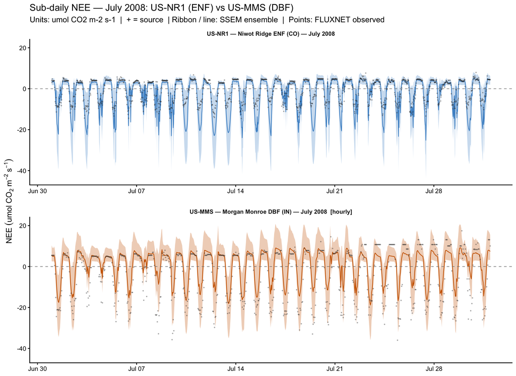

Sub-daily NEE during July 2008 at US-NR1 and US-MMS. Coloured ribbons: SSEM 95% credible interval. Coloured lines: SSEM ensemble median. Grey points: observed NEE at native sub-daily resolution. Note that US-MMS has half as many points per day (hourly) as US-NR1 (half-hourly). Units: μmol CO₂ m⁻² s⁻¹; positive = atmospheric source.

```r
# ── Panel 1: sub-daily NEE for July ──────────────────────────────────────────
# July is the peak-growing-season month at both sites, making the diurnal
# cycle most pronounced and differences in GPP magnitude most visible.
# Negative values (mid-day sink) dominate during daytime; respiration drives
# positive values at night.

# SSEM: extract July 2008 sub-daily steps for both sites
ssem_july <- ssem_subdaily |>
  filter(month(datetime) == 7L, year(datetime) == 2008L)

# FLUXNET: both primary sites, July 2008
fluxnet_july <- fluxnet_subdaily |>
  filter(
    site %in% c("US-NR1", "US-MMS"),
    year(datetime) == 2008L,
    month(datetime) == 7L
  )

july_labels <- c(
  "US-NR1" = "US-NR1 — Niwot Ridge ENF (CO) — July 2008",
  "US-MMS" = "US-MMS — Morgan Monroe DBF (IN) — July 2008  [hourly]"
)

ggplot(mapping = aes(x = datetime)) +
  geom_ribbon(
    data = ssem_july,
    aes(ymin = nee_lo, ymax = nee_hi, fill = site),
    alpha = 0.30
  ) +
  geom_line(
    data = ssem_july,
    aes(y = nee_med, colour = site),
    linewidth = 0.5
  ) +
  geom_point(
    data    = fluxnet_july,
    mapping = aes(y = nee_raw),
    colour  = "grey20", alpha = 0.30, size = 0.3
  ) +
  geom_hline(yintercept = 0, linetype = "dashed", colour = "grey50",
             linewidth = 0.35) +
  facet_wrap(
    ~ factor(site, levels = names(july_labels), labels = july_labels),
    ncol = 1, scales = "free_x"
  ) +
  scale_fill_manual(values  = c("US-NR1" = "steelblue3", "US-MMS" = "darkorange3"),
                    guide   = "none") +
  scale_colour_manual(values = c("US-NR1" = "steelblue3", "US-MMS" = "darkorange3"),
                      guide   = "none") +
  labs(
    title    = "Sub-daily NEE — July 2008: US-NR1 (ENF) vs US-MMS (DBF)",
    subtitle = paste("Units: umol CO2 m-2 s-1  |  + = source  |",
                     "Ribbon / line: SSEM ensemble  |  Points: FLUXNET observed"),
    x        = NULL,
    y        = expression(NEE ~ (umol ~ CO[2] ~ m^{-2} ~ s^{-1}))
  ) +
  theme_classic(base_size = 12) +
  theme(strip.background = element_blank(),
        strip.text        = element_text(face = "bold", size = 9),
        panel.spacing     = unit(1.2, "lines"))
```

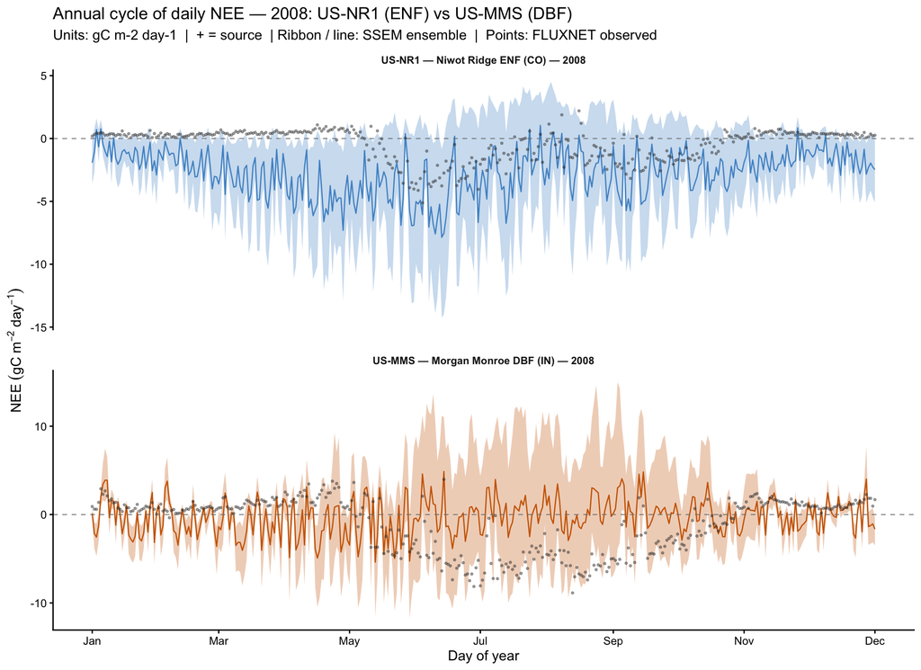

Annual cycle of daily NEE for 2008 at both primary sites. Coloured ribbons: SSEM 95% credible interval. Coloured lines: SSEM ensemble median. Grey points: FLUXNET daily NEE aggregated from sub-daily data. x-axis is day of year. Units: gC m⁻² day⁻¹; positive = source.

```r
# Filter each site to year 2008 (the SSEM run year)
annual_fluxnet <- fluxnet_daily |>
  filter(
    site %in% c("US-NR1", "US-MMS"),
    year(date) == 2008L
  ) |>
  mutate(doy = yday(date))

ssem_doy <- ssem_daily |>
  filter(year(date) == 2008L) |>
  mutate(doy = yday(date))

annual_labels <- c(
  "US-NR1" = "US-NR1 — Niwot Ridge ENF (CO) — 2008",
  "US-MMS" = "US-MMS — Morgan Monroe DBF (IN) — 2008"
)

ggplot(mapping = aes(x = doy)) +
  geom_ribbon(
    data = ssem_doy,
    aes(ymin = nee_lo, ymax = nee_hi, fill = site),
    alpha = 0.30
  ) +
  geom_line(
    data = ssem_doy,
    aes(y = nee_med, colour = site),
    linewidth = 0.5
  ) +
  geom_point(
    data    = annual_fluxnet,
    mapping = aes(y = nee_gCm2d),
    colour  = "grey20", alpha = 0.40, size = 0.6
  ) +
  geom_hline(yintercept = 0, linetype = "dashed", colour = "grey50",
             linewidth = 0.35) +
  facet_wrap(
    ~ factor(site, levels = names(annual_labels), labels = annual_labels),
    ncol = 1, scales = "free_y"
  ) +
  scale_fill_manual(values  = c("US-NR1" = "steelblue3", "US-MMS" = "darkorange3"),
                    guide   = "none") +
  scale_colour_manual(values = c("US-NR1" = "steelblue3", "US-MMS" = "darkorange3"),
                      guide   = "none") +
  scale_x_continuous(
    breaks = c(1, 60, 121, 182, 244, 305, 366),
    labels = c("Jan", "Mar", "May", "Jul", "Sep", "Nov", "Dec")
  ) +
  labs(
    title    = "Annual cycle of daily NEE — 2008: US-NR1 (ENF) vs US-MMS (DBF)",
    subtitle = paste("Units: gC m-2 day-1  |  + = source  |",
                     "Ribbon / line: SSEM ensemble  |  Points: FLUXNET observed"),
    x        = "Day of year",
    y        = expression(NEE ~ (gC ~ m^{-2} ~ day^{-1}))
  ) +
  theme_classic(base_size = 12) +
  theme(strip.background = element_blank(),
        strip.text        = element_text(face = "bold", size = 9),
        panel.spacing     = unit(1.2, "lines"))
```

## Cost functions

```r
# ── Cost function metrics at sub-daily and daily scales ───────────────────────
# Three metrics capture different aspects of model performance:
#
#   RMSE  — root mean square error: the typical magnitude of a single error.
#           Penalises large errors quadratically.  Units match the variable.
#
#   Bias  — mean(model − observation): non-zero bias = systematic offset.
#           Positive bias means model predicts a larger source (or smaller sink).
#
#   r     — Pearson correlation coefficient: whether the model tracks the
#           temporal pattern of observations, independent of absolute level.
#           A model can achieve r = 0.9 while having a large RMSE if the
#           seasonal shape is right but the amplitude is wrong.
#
# TIMESCALE DEPENDENCY — cost function values change with the timescale at
# which they are computed.  Daily metrics smooth over the diurnal cycle.
# Sub-daily metrics expose photosynthesis onset, stomatal responses, and
# nighttime respiration directly.  Neither timescale is universally "correct".

compute_metrics <- function(model_vec, obs_vec) {
  valid <- !is.na(model_vec) & !is.na(obs_vec)
  n     <- sum(valid)
  if (n < 2L) return(list(n = 0L, rmse = NA_real_, bias = NA_real_, r = NA_real_))
  res <- model_vec[valid] - obs_vec[valid]
  list(
    n    = n,
    rmse = sqrt(mean(res^2)),
    bias = mean(res),
    r    = cor(model_vec[valid], obs_vec[valid])
  )
}

# ── Sub-daily metrics (μmol CO₂ m⁻² s⁻¹) ────────────────────────────────────
# Join SSEM sub-daily timesteps with FLUXNET observations for 2008.
# Filter to well-measured timesteps: QC flag 0 (measured) or 1 (good gap-fill).

eval_subdaily <- function(site_label, fluxnet_sd, ssem_sd) {
  fluxnet_sd |>
    filter(site == site_label, year(datetime) == 2008L, nee_qc <= 1L) |>
    inner_join(
      ssem_sd |> filter(site == site_label) |> select(datetime, nee_med),
      by = "datetime"
    )
}

nr1_sd_eval  <- eval_subdaily("US-NR1", fluxnet_subdaily, ssem_subdaily)
mms_sd_eval  <- eval_subdaily("US-MMS", fluxnet_subdaily, ssem_subdaily)

sd_nr1 <- compute_metrics(nr1_sd_eval$nee_med, nr1_sd_eval$nee_raw)
sd_mms <- compute_metrics(mms_sd_eval$nee_med, mms_sd_eval$nee_raw)

# ── Daily metrics (gC m⁻² day⁻¹) ─────────────────────────────────────────────
eval_daily <- function(site_label, fluxnet_dd, ssem_dd) {
  fluxnet_dd |>
    filter(site == site_label, year(date) == 2008L,
           !is.na(nee_gCm2d), nee_qc_mean <= 1.0) |>
    inner_join(
      ssem_dd |> filter(site == site_label) |> select(date, nee_med),
      by = "date"
    )
}

nr1_dd_eval  <- eval_daily("US-NR1", fluxnet_daily, ssem_daily)
mms_dd_eval  <- eval_daily("US-MMS", fluxnet_daily, ssem_daily)

dd_nr1 <- compute_metrics(nr1_dd_eval$nee_med, nr1_dd_eval$nee_gCm2d)
dd_mms <- compute_metrics(mms_dd_eval$nee_med, mms_dd_eval$nee_gCm2d)

# ── Summary table ─────────────────────────────────────────────────────────────
metrics_tbl <- tibble(
  Site        = rep(c("US-NR1", "US-MMS"), each = 2L),
  Timescale   = rep(c("Sub-daily", "Daily"), times = 2L),
  Units       = rep(c("μmol m⁻² s⁻¹", "gC m⁻² day⁻¹"), times = 2L),
  N           = c(sd_nr1$n,  dd_nr1$n,  sd_mms$n,  dd_mms$n),
  RMSE        = c(sd_nr1$rmse, dd_nr1$rmse, sd_mms$rmse, dd_mms$rmse),
  Bias        = c(sd_nr1$bias, dd_nr1$bias, sd_mms$bias, dd_mms$bias),
  Correlation = c(sd_nr1$r,  dd_nr1$r,  sd_mms$r,  dd_mms$r)
)

cat("── Cost function metrics: SSEM ensemble median vs FLUXNET NEE ──────────\n")
```

```
## ── Cost function metrics: SSEM ensemble median vs FLUXNET NEE ──────────
```

```r
cat("   Both sites: 2008.  US-NR1 uses NEE_CUT_REF; US-MMS uses NEE_VUT_REF.\n\n")
```

```
##    Both sites: 2008.  US-NR1 uses NEE_CUT_REF; US-MMS uses NEE_VUT_REF.
```

```r
metrics_tbl |>
  mutate(across(c(RMSE, Bias, Correlation), \(x) round(x, 3))) |>
  print(n = Inf)
```

```
## # A tibble: 4 × 7
##   Site   Timescale Units            N  RMSE   Bias Correlation
##   <chr>  <chr>     <chr>        <int> <dbl>  <dbl>       <dbl>
## 1 US-NR1 Sub-daily μmol m⁻² s⁻¹ 17165  5.37 -2.26        0.698
## 2 US-NR1 Daily     gC m⁻² day⁻¹   346  2.85 -2.33        0.46
## 3 US-MMS Sub-daily μmol m⁻² s⁻¹  7902  5.87  0.693       0.664
## 4 US-MMS Daily     gC m⁻² day⁻¹   296  3.27  0.143       0.111
```

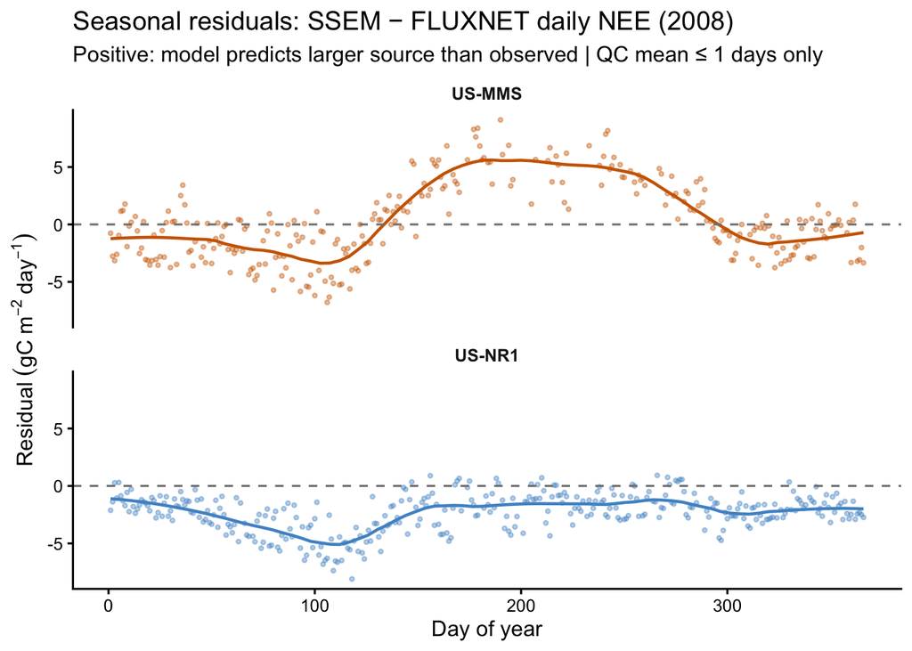

```r
# ── Seasonal residual plots at daily scale ────────────────────────────────────
residuals_dd <- bind_rows(
  nr1_dd_eval |> mutate(residual = nee_med - nee_gCm2d, doy = yday(date)),
  mms_dd_eval |> mutate(residual = nee_med - nee_gCm2d, doy = yday(date))
)

residuals_dd |>
  ggplot(aes(x = doy, y = residual, colour = site)) +
    geom_point(alpha = 0.40, size = 0.8) +
    geom_smooth(method = "loess", span = 0.3, se = FALSE, linewidth = 0.8) +
    geom_hline(yintercept = 0, linetype = "dashed", colour = "grey50") +
    scale_colour_manual(values = c("US-NR1" = "steelblue3", "US-MMS" = "darkorange3")) +
    facet_wrap(~ site, ncol = 1) +
    labs(
      title    = "Seasonal residuals: SSEM − FLUXNET daily NEE (2008)",
      subtitle = "Positive: model predicts larger source than observed | QC mean ≤ 1 days only",
      x        = "Day of year",
      y        = expression(Residual ~ (gC ~ m^{-2} ~ day^{-1}))
    ) +
    theme_classic(base_size = 12) +
    theme(strip.background = element_blank(),
          strip.text        = element_text(face = "bold"),
          legend.position   = "none")
```

## CMIP6 comparison

> **Choose your model.** Set `chosen_model` to one of: `"CESM2"`, `"IPSL-CM6A-LR"`, `"UKESM1-0-LL"`

> **CMIP6 and FLUXCOM data availability.** CMIP6 model output has been pre-extracted for the grid cells nearest to all four sites (US-NR1, US-MMS, DE-Tha, DK-Sor) using `data/cmip6/extract_cmip6_allsites.py`. FLUXCOM-X-BASE monthly data have likewise been extracted for all four sites using `data/fluxcom/extract_fluxcom_allsites.py`. Set `chosen_site` and `chosen_model` below to work with your primary site.

```r
# ── USER SELECTION ────────────────────────────────────────────────────────────
chosen_site  <- "US-NR1"      # options: "US-NR1", "US-MMS", "DE-Tha", "DK-Sor"
chosen_model <- "CESM2"       # options: "CESM2", "IPSL-CM6A-LR", "UKESM1-0-LL"
# ─────────────────────────────────────────────────────────────────────────────

stopifnot(
  "`chosen_site` must be 'US-NR1', 'US-MMS', 'DE-Tha', or 'DK-Sor'" =
    chosen_site %in% c("US-NR1", "US-MMS", "DE-Tha", "DK-Sor"),
  "`chosen_model` must be 'CESM2', 'IPSL-CM6A-LR', or 'UKESM1-0-LL'" =
    chosen_model %in% c("CESM2", "IPSL-CM6A-LR", "UKESM1-0-LL")
)
cat("Comparing:", chosen_site, "vs", chosen_model, "\n")
```

```
## Comparing: US-NR1 vs CESM2
```

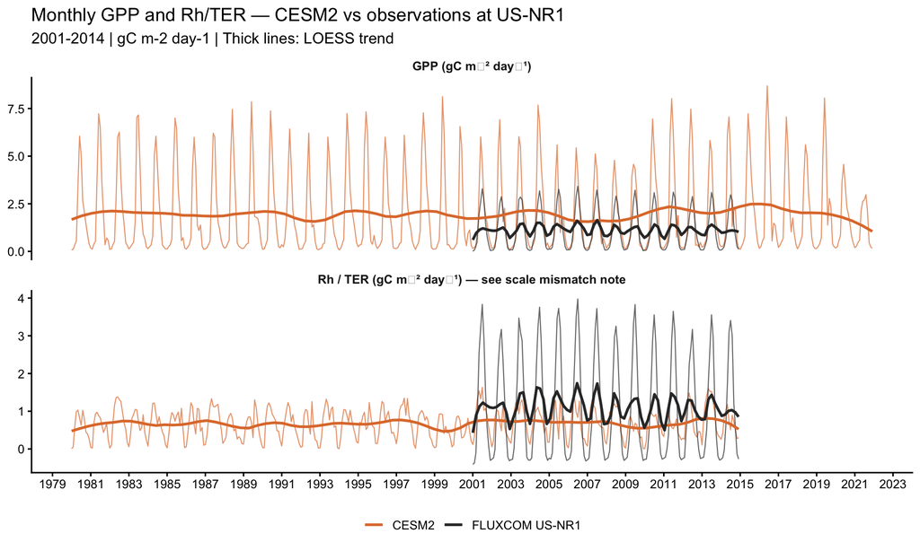

```r
# Load CMIP6 for the chosen site (US-NR1 and US-MMS already in memory;
# DE-Tha and DK-Sor are loaded on demand to avoid loading all 12 CSVs upfront)
cmip6_site_raw <- switch(
  chosen_site,
  "US-NR1" = cmip6_nr1_raw,
  "US-MMS" = cmip6_mms_raw,
  load_cmip6_site(chosen_site)   # DE-Tha or DK-Sor: load now
)
cmip6_site <- harmonise_cmip6(cmip6_site_raw)

cmip6_chosen <- cmip6_site |>
  filter(model == chosen_model) |>
  mutate(date = as.Date(paste(year, month, "01", sep = "-")))

# Aggregate the US-MMS FLUXNET daily file to monthly means for comparison.
# For US-NR1 and the extension sites, we use the FLUXCOM monthly estimate as
# the observational reference for the CMIP6 comparison (tower and CMIP6 grid
# cells are not directly comparable in scale; FLUXCOM bridges that gap).
usmms_monthly <- usmms_raw |>
  mutate(date = as.Date(DATE)) |>
  filter(year(date) >= 1999, year(date) <= 2014) |>
  mutate(across(where(is.numeric), \(x) replace(x, x == -9999, NA))) |>
  mutate(
    gpp_gCm2d  = GPP_NT_VUT_REF  * UMOL_S_TO_GC_DAY,
    reco_gCm2d = RECO_NT_VUT_REF * UMOL_S_TO_GC_DAY
  ) |>
  group_by(year = year(date), month = month(date)) |>
  summarise(
    gpp_gCm2d  = mean(gpp_gCm2d,  na.rm = TRUE),
    reco_gCm2d = mean(reco_gCm2d, na.rm = TRUE),
    .groups    = "drop"
  ) |>
  mutate(date = as.Date(paste(year, month, "01", sep = "-")))

# Choose the observational reference for the comparison plot:
# US-MMS → FLUXNET monthly means; other sites → FLUXCOM monthly GPP/TER
if (chosen_site == "US-MMS") {
  obs_long <- usmms_monthly |>
    select(date, GPP = gpp_gCm2d, Rh = reco_gCm2d) |>
    pivot_longer(c(GPP, Rh), names_to = "variable", values_to = "value") |>
    mutate(source = paste("FLUXNET", chosen_site))
} else {
  # Use FLUXCOM as the landscape-scale observational reference
  fc <- if (chosen_site == "US-NR1") fluxcom_nr1 else load_fluxcom_site(chosen_site)
  obs_long <- if (!is.null(fc)) {
    fc |>
      filter(year >= 2001, year <= 2014) |>
      mutate(date = as.Date(paste(year, month, "01", sep = "-"))) |>
      select(date, GPP = GPP_gC_m2_d, Rh = TER_gC_m2_d) |>
      pivot_longer(c(GPP, Rh), names_to = "variable", values_to = "value") |>
      mutate(source = paste("FLUXCOM", chosen_site))
  } else tibble()
}

cmip6_long <- cmip6_chosen |>
  select(date, GPP = gpp_gCm2d, Rh = rh_gCm2d) |>
  pivot_longer(c(GPP, Rh), names_to = "variable", values_to = "value") |>
  mutate(source = chosen_model)

bind_rows(cmip6_long, obs_long) |>
  ggplot(aes(x = date, y = value, colour = source)) +
    geom_line(linewidth = 0.4, alpha = 0.7) +
    geom_smooth(method = "loess", span = 0.15, se = FALSE,
                linewidth = 1.0, na.rm = TRUE) +
    facet_wrap(~ variable, ncol = 1, scales = "free_y",
               labeller = as_labeller(c(
                 GPP = "GPP (gC m⁻² day⁻¹)",
                 Rh  = "Rh / TER (gC m⁻² day⁻¹) — see scale mismatch note"
               ))) +
    scale_colour_manual(
      values = c(
        "FLUXNET US-MMS"  = "grey20",
        "FLUXCOM US-NR1"  = "grey20",
        "FLUXCOM DE-Tha"  = "grey20",
        "FLUXCOM DK-Sor"  = "grey20",
        "CESM2"           = "#E07B39",
        "IPSL-CM6A-LR"    = "#5B8DB8",
        "UKESM1-0-LL"     = "#6BAE75"
      )
    ) +
    scale_x_date(date_breaks = "2 years", date_labels = "%Y") +
    labs(
      title    = paste("Monthly GPP and Rh/TER —", chosen_model, "vs observations at", chosen_site),
      subtitle = "2001-2014 | gC m-2 day-1 | Thick lines: LOESS trend",
      x        = NULL,
      y        = NULL,
      colour   = NULL
    ) +
    theme_classic(base_size = 12) +
    theme(
      legend.position  = "bottom",
      strip.background = element_blank(),
      strip.text       = element_text(face = "bold")
    )
```

> **Scale mismatch and FLUXCOM as a bridge.** Each CMIP6 grid cell represents roughly 1° × 1° of latitude — approximately 100 km × 70 km at mid-latitudes. That single number blends every land cover type in the cell. The flux tower footprint covers a few hundred metres to ~2 km. FLUXCOM-X-BASE (Nelson et al. 2024) bridges this gap: it is trained on thousands of tower-years but predicts fluxes on a 0.5° grid, making it a better observational reference when comparing to CMIP6 than a single tower alone. For US-MMS (which provides a DD FLUXNET daily file), the FLUXNET monthly mean is used directly. For other sites, the FLUXCOM monthly estimate is the landscape-scale reference. Ask: does the model reproduce the *direction* of the seasonal cycle? Does its interannual variability correlate with observations? Does its decadal trend match the atmospheric record?

## FLUXCOM comparison

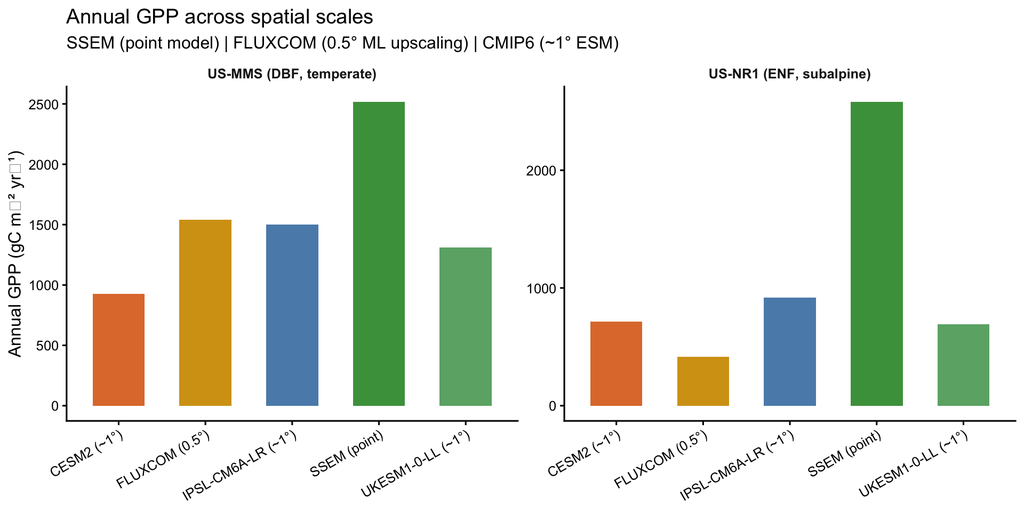

Annual GPP from SSEM, FLUXCOM-X-BASE, and the three CMIP6 models at both primary sites (US-NR1 and US-MMS). FLUXCOM mediates the spatial scale mismatch: it provides a 0.5° landscape estimate comparable to the CMIP6 grid cell, while SSEM simulates the same small forest stand as the tower.

```r
# Build annual GPP totals (gC m-2 yr-1) for all products at both primary sites
# so students can see the full hierarchy: SSEM < FLUXCOM < CMIP6 scale chain.

annual_gpp_list <- list()

# SSEM annual GPP (gC m-2 yr-1): sum daily median GPP over the run year.
# ssem_daily is the combined tibble (from the harmonise chunk) with site,
# date, gpp_med (gC m-2 d-1); summing gives annual gC m-2 yr-1 for the run year.
for (site_id in c("US-NR1", "US-MMS")) {
  ann <- ssem_daily |>
    dplyr::filter(site == site_id) |>
    dplyr::summarise(
      source  = paste("SSEM", site_id),
      gpp_ann = sum(gpp_med, na.rm = TRUE)
    )
  annual_gpp_list[[paste0("SSEM_", site_id)]] <- ann
}

# FLUXCOM annual GPP (gC m-2 yr-1): sum of monthly (gC m-2 d-1) × days-in-month
for (pair in list(list("US-NR1", fluxcom_nr1), list("US-MMS", fluxcom_mms))) {
  site_id <- pair[[1]]; fc <- pair[[2]]
  if (!is.null(fc)) {
    fc_ann <- fc |>
      dplyr::mutate(
        days = lubridate::days_in_month(date),
        gpp_monthly = GPP_gC_m2_d * days
      ) |>
      dplyr::group_by(year) |>
      dplyr::summarise(gpp_ann = sum(gpp_monthly, na.rm = TRUE), .groups = "drop") |>
      dplyr::summarise(
        source  = paste("FLUXCOM", site_id),
        gpp_ann = mean(gpp_ann, na.rm = TRUE)   # mean across 2001-2021
      )
    annual_gpp_list[[paste0("FLUXCOM_", site_id)]] <- fc_ann
  }
}

# CMIP6 annual GPP (gC m-2 yr-1): sum of monthly (gC m-2 d-1) × days-in-month
for (pair in list(list("US-NR1", cmip6_nr1), list("US-MMS", cmip6_mms))) {
  site_id <- pair[[1]]; cm <- pair[[2]]
  cm_ann <- cm |>
    dplyr::mutate(
      days = lubridate::days_in_month(as.Date(paste(year, month, "01", sep="-"))),
      gpp_monthly = gpp_gCm2d * days
    ) |>
    dplyr::filter(year >= 2001, year <= 2014) |>
    dplyr::group_by(model, year) |>
    dplyr::summarise(gpp_ann = sum(gpp_monthly, na.rm = TRUE), .groups = "drop") |>
    dplyr::group_by(model) |>
    dplyr::summarise(gpp_ann = mean(gpp_ann, na.rm = TRUE), .groups = "drop") |>
    dplyr::mutate(source = paste(model, site_id))
  for (i in seq_len(nrow(cm_ann))) {
    annual_gpp_list[[paste0(cm_ann$model[i], "_", site_id)]] <- cm_ann[i, ] |>
      select(source, gpp_ann)
  }
}

# Combine and plot
ann_df <- dplyr::bind_rows(annual_gpp_list) |>
  dplyr::mutate(
    site    = dplyr::case_when(
      grepl("NR1", source) ~ "US-NR1 (ENF, subalpine)",
      grepl("MMS", source) ~ "US-MMS (DBF, temperate)"
    ),
    product = dplyr::case_when(
      grepl("^SSEM",    source) ~ "SSEM (point)",
      grepl("^FLUXCOM", source) ~ "FLUXCOM (0.5°)",
      grepl("CESM2",    source) ~ "CESM2 (~1°)",
      grepl("IPSL",     source) ~ "IPSL-CM6A-LR (~1°)",
      grepl("UKESM",    source) ~ "UKESM1-0-LL (~1°)"
    )
  )

ggplot(ann_df |> tidyr::drop_na(site, product),
       aes(x = product, y = gpp_ann, fill = product)) +
  geom_col(width = 0.6) +
  facet_wrap(~ site, ncol = 2, scales = "free_y") +
  labs(
    title    = "Annual GPP across spatial scales",
    subtitle = "SSEM (point model) | FLUXCOM (0.5° ML upscaling) | CMIP6 (~1° ESM)",
    x        = NULL,
    y        = "Annual GPP (gC m⁻² yr⁻¹)",
    fill     = NULL
  ) +
  scale_fill_manual(values = c(
    "SSEM (point)"       = "#4a9e4a",
    "FLUXCOM (0.5°)"     = "#d4a017",
    "CESM2 (~1°)"        = "#E07B39",
    "IPSL-CM6A-LR (~1°)" = "#5B8DB8",
    "UKESM1-0-LL (~1°)"  = "#6BAE75"
  )) +
  theme_classic(base_size = 12) +
  theme(
    axis.text.x      = element_text(angle = 30, hjust = 1),
    strip.background = element_blank(),
    strip.text       = element_text(face = "bold"),
    legend.position  = "none"
  )
```

## Export data for further analysis

```r
output_dir <- "output"
if (!dir.exists(output_dir)) dir.create(output_dir, recursive = TRUE)

# ── Helper: export one SSEM site ─────────────────────────────────────────────
export_ssem_site <- function(ssem_info, site_label) {
  step_conv <- ssem_info$step_conv
  day_idx   <- ssem_info$day_idx
  dates_s   <- ssem_info$dates
  ssem_out  <- ssem_info$ssem_out

  nee_m     <- -ssem_out[,, 6]
  ra_ens    <- apply(ssem_out[,, 7],  2, \(e) tapply(e, day_idx, sum) * step_conv)
  rh_ens    <- apply(ssem_out[,, 10], 2, \(e) tapply(e, day_idx, sum) * step_conv)
  nee_ci    <- apply(apply(nee_m, 2, \(e) tapply(e, day_idx, sum) * step_conv),
                     1, quantile, c(0.025, 0.5, 0.975), na.rm = TRUE)
  gpp_ci    <- apply(apply(ssem_out[,, 5], 2, \(e) tapply(e, day_idx, sum) * step_conv),
                     1, quantile, c(0.025, 0.5, 0.975), na.rm = TRUE)
  ra_ci     <- apply(ra_ens, 1, quantile, c(0.025, 0.5, 0.975), na.rm = TRUE)
  rh_ci     <- apply(rh_ens, 1, quantile, c(0.025, 0.5, 0.975), na.rm = TRUE)

  tbl <- tibble(
    datetime    = dates_s,
    NEP_median  = -nee_ci["50%",  ],
    NEP_lower95 = -nee_ci["97.5%",],
    NEP_upper95 = -nee_ci["2.5%", ],
    GPP_median  =  gpp_ci["50%",  ],
    Ra_median   =   ra_ci["50%",  ],
    Rh_median   =   rh_ci["50%",  ]
  )
  out_file <- file.path(output_dir, sprintf("ssem_%s.csv", site_label))
  write_csv(tbl, out_file)
  cat(sprintf("Saved: %s  (%d rows)\n", out_file, nrow(tbl)))
}

export_ssem_site(nr1_ssem, "US-NR1")
```

```
## Saved: output/ssem_US-NR1.csv  (366 rows)
```

```r
export_ssem_site(mms_ssem, "US-MMS")
```

```
## Saved: output/ssem_US-MMS.csv  (366 rows)
```

```r
# ── FLUXNET daily observations ────────────────────────────────────────────────
obs_dd_files <- list(
  "US-NR1" = file.path(data_dir, "US-NR1", "US-NR1_DD.csv"),
  "US-MMS" = file.path(data_dir, "US-MMS", "US-MMS_DD.csv")
)
for (s in names(obs_dd_files)) {
  fpath <- obs_dd_files[[s]]
  if (!file.exists(fpath)) {
    cat(sprintf("Skipping obs_%s_daily.csv — DD file not found\n", s))
    next
  }
  # US-NR1 uses NEE_CUT_REF; US-MMS uses NEE_VUT_REF
  nee_col  <- if (s == "US-NR1") "NEE_CUT_REF"  else "NEE_VUT_REF"
  gpp_col  <- if (s == "US-NR1") "GPP_NT_CUT_REF"  else "GPP_NT_VUT_REF"
  reco_col <- if (s == "US-NR1") "RECO_NT_CUT_REF" else "RECO_NT_VUT_REF"

  obs_df <- read_csv(fpath, show_col_types = FALSE) |>
    mutate(across(where(is.numeric), \(x) replace(x, x == -9999, NA)))

  # Only keep columns that actually exist in this product
  available_cols <- intersect(c("DATE", nee_col, gpp_col, reco_col), names(obs_df))
  obs_df <- obs_df |>
    select(all_of(available_cols)) |>
    mutate(date = as.Date(as.character(DATE)))

  if (nee_col  %in% names(obs_df)) obs_df <- obs_df |> mutate(NEE_gC_m2_day  = .data[[nee_col]]  * UMOL_S_TO_GC_DAY)
  if (gpp_col  %in% names(obs_df)) obs_df <- obs_df |> mutate(GPP_gC_m2_day  = .data[[gpp_col]]  * UMOL_S_TO_GC_DAY)
  if (reco_col %in% names(obs_df)) obs_df <- obs_df |> mutate(RECO_gC_m2_day = .data[[reco_col]] * UMOL_S_TO_GC_DAY)

  out_cols <- intersect(c("date","NEE_gC_m2_day","GPP_gC_m2_day","RECO_gC_m2_day"),
                        names(obs_df))
  obs_df <- obs_df |> select(all_of(out_cols))
  out_file <- file.path(output_dir, sprintf("obs_%s_daily.csv", s))
  write_csv(obs_df, out_file)
  cat(sprintf("Saved: %s  (%d rows)\n", out_file, nrow(obs_df)))
}
```

```
## Saved: output/obs_US-NR1_daily.csv  (10227 rows)
## Saved: output/obs_US-MMS_daily.csv  (9131 rows)
```

```r
# ── CMIP6 model output ────────────────────────────────────────────────────────
cmip6_out_name <- sprintf("cmip6_%s_%s.csv", chosen_site, chosen_model)
write_csv(cmip6_chosen, file.path(output_dir, cmip6_out_name))
cat(sprintf("Saved: %s  (%d rows)\n",
            file.path(output_dir, cmip6_out_name), nrow(cmip6_chosen)))
```

```
## Saved: output/cmip6_US-NR1_CESM2.csv  (504 rows)
```

```r
message("
Output files saved to exercises/output/
  ssem_US-NR1.csv, ssem_US-MMS.csv          — SSEM daily ensemble output
  obs_US-NR1_daily.csv, obs_US-MMS_daily.csv — FLUXNET daily observations
  cmip6_{site}_{model}.csv                   — CMIP6 monthly model output (chosen site)
")
```

```
##
## Output files saved to exercises/output/
##   ssem_US-NR1.csv, ssem_US-MMS.csv          — SSEM daily ensemble output
##   obs_US-NR1_daily.csv, obs_US-MMS_daily.csv — FLUXNET daily observations
##   cmip6_{site}_{model}.csv                   — CMIP6 monthly model output (chosen site)
```

## Discussion questions

Work through all four questions before you leave the session.

**1. Which site does SSEM perform better on, and why?** Look at the visual comparison and the cost function table for US-NR1 and US-MMS. At which site does SSEM more closely reproduce the seasonal timing and magnitude of NEE? Does the ENF (US-NR1) or DBF (US-MMS) present a more demanding test for SSEM’s simple structure? Consider the specific parameter differences between the two runs — what was changed, and what was kept the same?

**2. What do the seasonal residuals tell you about what is missing?** Look at the residual plots for each site. Are the errors random throughout the year, or do they have a systematic seasonal structure? If they are larger in summer than in winter, or systematically positive in spring and negative in autumn, what process does that implicate? Consider the list of things SSEM ignores — water stress, VPD limitation, phenology — and identify which omission is most consistent with the pattern you observe at each site.

**3. ENF vs DBF: what would you need to add to SSEM?** US-MMS is deciduous — it has near-zero GPP in winter and a rapid spring onset driven by photoperiod and temperature. SSEM has no phenology module: Bleaf changes only as the balance between NPPleaf allocation and the constant litterfall rate, producing a gradual rather than abrupt seasonal cycle. Sketch (in words, not code) what equations you would need to add to SSEM to reproduce a realistic deciduous phenology. What driver variables would those equations require, and are those drivers available in the current data files? Would the same phenology module work at US-NR1 (an evergreen site)?

**4. Would you trust a forecast from this model?** Imagine a stakeholder (a forest manager, a carbon credit verification service, a national carbon inventory) asked you to use SSEM to project annual NEE five years into the future at US-NR1 or US-MMS under a warming scenario. Based on the validation you have done, what would you tell them? Be specific: what does the model get right that you could defend, what does it get wrong that you could not defend, and what additional validation steps would you require before presenting the forecast as credible? Does your answer differ between the ENF and DBF site?